# DiscreteCharacters

Brian O’Meara

2/16/2017

For this exercise, explore looking at discrete character models.

Remember for homework, change `eval=TRUE` for all the R blocks, debug, commit, and do a pull request.

These are useful packages in this area (far from exhaustive list).

```r
library(ape)
library(geiger)
library(phytools)
library(phangorn)
```

library(ape)

You’ll need to get data into R in some way.

```r
tree <- read.tree("Maggie_nexus.tre")
discrete.data <- read.delim(file="edriodata.csv",stringsAsFactors=FALSE)
ape::compute.brlen(tree)
```

```
##
## Phylogenetic tree with 15 tips and 12 internal nodes.
##
## Tip labels:
##  Carneyella_pilea, Isorophus_cincinnatiensis, Isorophusella_spp., Neoisorophysella_lanei, Foerstediscus_grandis, Agelacrinites_hamiltonensis, ...
##
## Unrooted; includes branch lengths.
```

```r
tree<-ape::compute.brlen(tree)
```

Data are often not right in some way. They might not match the taxa in your tree, there may be missing data, etc. `geiger::treedata` is a great function for getting a tree and data that match, but your data may need other cleaning. Do it as a function so it’s repeatable.

```r
CleanData <- function(tree, discrete.data) {
  tree$tip.label <- gsub("_", " ", tree$tip.label)
  rownames(discrete.data) <- discrete.data[,1]
  # make it a character matrix
  discrete.data <- as.matrix(discrete.data[,-1])
  # define ambiguous states "N" and "?"
  data <- phyDat(as.matrix(discrete.data), type="USER", levels=c("0", "1", "2"), ambiguity = c("N", "?"))
  # reorder data
  data <- subset(data, tree$tip.label)
  list(phy=tree, data = data)
}

cleaned.results <- CleanData(tree, discrete.data)
cleaned.tree <- cleaned.results$phy
cleaned.data <- cleaned.results$data

match(cleaned.tree$tip.label, names(cleaned.data))  # should be 1:15
```

```
##  [1]  1  2  3  4  5  6  7  8  9 10 11 12 13 14 15
```

```r
as.character(cleaned.data) # should look like the original
```

```
##                              [,1] [,2] [,3] [,4] [,5] [,6] [,7] [,8] [,9]
## Carneyella pilea             "0"  "0"  "0"  "1"  "0"  "0"  "0"  "0"  "0"
## Isorophus cincinnatiensis    "0"  "1"  "0"  "1"  "1"  "0"  "0"  "0"  "0"
## Isorophusella spp.           "0"  "1"  "1"  "1"  "1"  "0"  "0"  "0"  "0"
## Neoisorophysella lanei       "0"  "N"  "1"  "0"  "1"  "1"  "0"  "?"  "0"
## Foerstediscus grandis        "0"  "0"  "0"  "0"  "0"  "0"  "0"  "0"  "0"
## Agelacrinites hamiltonensis  "1"  "N"  "0"  "0"  "1"  "0"  "0"  "0"  "0"
## Stalticodiscus milleri       "1"  "N"  "0"  "0"  "1"  "1"  "1"  "1"  "0"
## Ulrichidiscus pulaskiensis   "1"  "N"  "0"  "0"  "1"  "1"  "1"  "1"  "0"
## Lepidodiscus laudoni         "1"  "N"  "0"  "0"  "1"  "1"  "1"  "1"  "1"
## Chester Lepidodiscus laudoni "1"  "N"  "0"  "0"  "1"  "1"  "1"  "1"  "1"
## Discocystis kaskaskiensis    "1"  "N"  "0"  "0"  "1"  "1"  "1"  "1"  "1"
## Lispidecodus                 "1"  "N"  "0"  "?"  "1"  "1"  "1"  "1"  "1"
## Cooperidiscus                "?"  "?"  "1"  "?"  "?"  "?"  "?"  "?"  "?"
## Lepidodiscus squamosus       "1"  "N"  "0"  "0"  "1"  "1"  "1"  "1"  "0"
## Postibulla legrandensis      "1"  "N"  "0"  "0"  "1"  "0"  "1"  "0"  "0"
##                              [,10] [,11] [,12] [,13] [,14] [,15] [,16]
## Carneyella pilea             "0"   "0"   "0"   "0"   "0"   "0"   "0"
## Isorophus cincinnatiensis    "0"   "0"   "0"   "0"   "0"   "0"   "0"
## Isorophusella spp.           "0"   "0"   "0"   "0"   "0"   "0"   "1"
## Neoisorophysella lanei       "0"   "0"   "0"   "0"   "0"   "0"   "1"
## Foerstediscus grandis        "0"   "0"   "0"   "0"   "0"   "0"   "0"
## Agelacrinites hamiltonensis  "1"   "0"   "0"   "1"   "0"   "0"   "0"
## Stalticodiscus milleri       "0"   "0"   "0"   "1"   "1"   "0"   "0"
## Ulrichidiscus pulaskiensis   "1"   "1"   "0"   "1"   "1"   "0"   "0"
## Lepidodiscus laudoni         "1"   "1"   "0"   "1"   "1"   "0"   "0"
## Chester Lepidodiscus laudoni "1"   "2"   "1"   "1"   "1"   "1"   "0"
## Discocystis kaskaskiensis    "1"   "2"   "1"   "1"   "1"   "1"   "0"
## Lispidecodus                 "0"   "2"   "?"   "1"   "1"   "1"   "?"
## Cooperidiscus                "1"   "1"   "?"   "1"   "?"   "0"   "0"
## Lepidodiscus squamosus       "0"   "0"   "0"   "0"   "1"   "0"   "0"
## Postibulla legrandensis      "0"   "0"   "0"   "1"   "0"   "0"   "0"
##                              [,17] [,18] [,19] [,20] [,21] [,22] [,23]
## Carneyella pilea             "0"   "0"   "0"   "0"   "0"   "0"   "0"
## Isorophus cincinnatiensis    "0"   "0"   "0"   "0"   "0"   "0"   "0"
## Isorophusella spp.           "N"   "N"   "N"   "0"   "0"   "0"   "0"
## Neoisorophysella lanei       "N"   "N"   "N"   "0"   "0"   "0"   "0"
## Foerstediscus grandis        "0"   "0"   "0"   "0"   "0"   "0"   "0"
## Agelacrinites hamiltonensis  "0"   "0"   "0"   "0"   "0"   "0"   "0"
## Stalticodiscus milleri       "1"   "0"   "0"   "0"   "0"   "0"   "0"
```

[output cut: 9 more lines]

```
## Carneyella pilea             "0"   "N"
## Isorophus cincinnatiensis    "0"   "N"
## Isorophusella spp.           "0"   "N"
## Neoisorophysella lanei       "0"   "N"
## Foerstediscus grandis        "0"   "N"
## Agelacrinites hamiltonensis  "0"   "N"
## Stalticodiscus milleri       "0"   "N"
## Ulrichidiscus pulaskiensis   "0"   "0"
## Lepidodiscus laudoni         "1"   "1"
## Chester Lepidodiscus laudoni "1"   "1"
## Discocystis kaskaskiensis    "1"   "1"
## Lispidecodus                 "0"   "1"
## Cooperidiscus                "?"   "?"
## Lepidodiscus squamosus       "0"   "N"
## Postibulla legrandensis      "0"   "N"
```

It’s critically important to LOOK at what you have. Are there weird values? Has the match between taxa and state gone correctly? Do you think you have binary data, but there’s actually only state 1? Especially as data sets grow (yay), and are assembled using scripts rather than by error-prone, non-reproducable hands (double yay), scientists are increasingly less likely to deeply look at our data. That’s bad – don’t be that person.

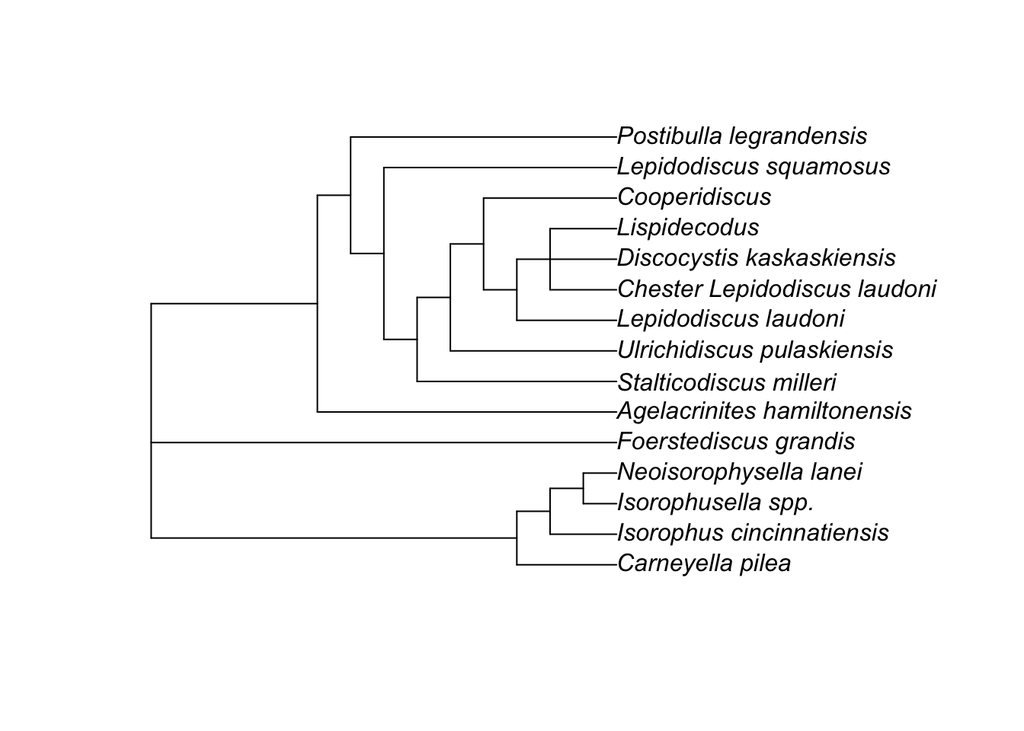

```
## 15 sequences with 25 character and 23 different site patterns.
## The states are 0 1 2
```

```r
VisualizeData <- function(tree, data) {
  plot(tree)
  print(data)
}

VisualizeData(cleaned.tree, cleaned.data)
```

```r
discrete.data.matrix <- as.matrix(cleaned.data)
rownames(discrete.data.matrix) <- rownames(cleaned.data)

print(discrete.data.matrix)
```

```
## 15 sequences with 25 character and 23 different site patterns.
## The states are 0 1 2
```

First, let’s use parsimony to look at ancestral states:

```r
anc.p <- ancestral.pars(cleaned.tree, cleaned.data)
print(anc.p)
```

```
## 27 sequences with 25 character and 23 different site patterns.
## The states are 0 1 2
```

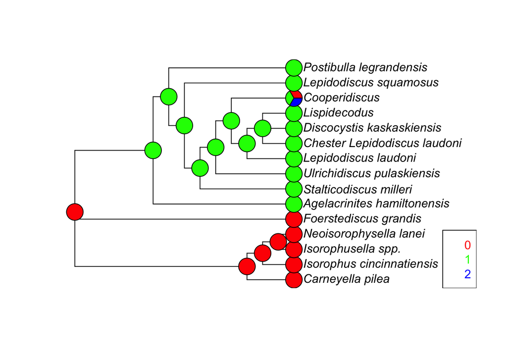

```r
plotAnc(tree, anc.p, attr(anc.p, "index")[1])
```

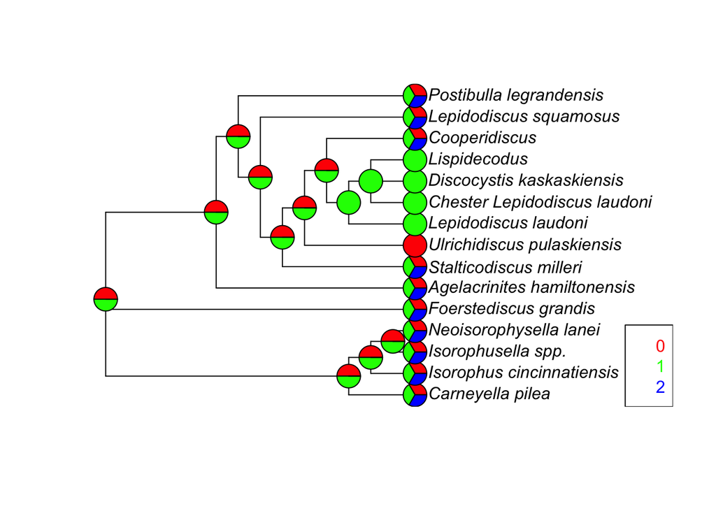

```r
plotAnc(tree, anc.p, attr(anc.p, "index")[25])
```

Do you see uncertainty? What does it mean?

Now, plot the likelihood estimates.

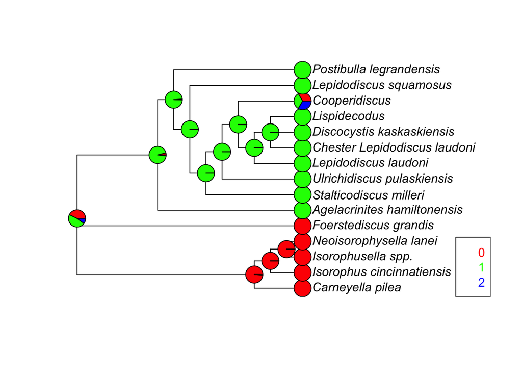

```r
anc.ml <- ancestral.pml(pml(cleaned.tree, cleaned.data), type="ml")
plotAnc(tree, anc.ml, 1)
```

Why does it differ from parsimony?

What does uncertainty mean?

Now, to the biological questions. For many of these, `corHMM` will be a useful package.

1. How can you estimate transition rates between states? Do it.
2. How could you examine if transition rates are equal?
3. Think about the Lewis (2001) MKV model. Are your traits all variable? Will using this make sense for your data? Try using it. Do results change?
4. How could you test order of state evolution?